# Cats Cradle Spatial Vignette

If the xenium object is downloaded we can read this to enable the spatial visualisation of results.

```r
#xenium.obj = read.rds("/path/to/xenium.obj.rds")
```

Compute spatial neighbours based on Delaunay triangulation.

```r
delaunayNeighbours = computeNeighboursDelaunay(centroids)
```

Alternatively compute neighbours based on Euclidean distance.

```r
euclideanNeighbours = computeNeighboursEuclidean(centroids, 20)
```

Compute neighbourhoods, here each a neighbourhood is computed for each cell that comprises of its 1st degree neighbours. Set “addSelf = T” to include the central cell in its neighbourhood.

```r
neighbourhood = computeNeighbourhoods(delaunayNeighbours, names(clusters))
```

Compute a matrix where neighbourhoods are rows and cell types are columns. The values in the matrix indicate the number of cells of a given type within a neighbourhood.

```r
neighbourhoodbyCTmatrix = computeNeighbourhoodByCTMatrix(neighbourhood,
                                                         clusters)
```

Create a seurat object using a neighbourhood by cell type matrix and calculate UMAP and clusters. As the dimensionlity of the feature space is relatively low (number of cell types) we calculate the UMAP using features rather than PCs.

```r
neighbourhoodSeurat = computeNeighbourhoodByCTSeurat(neighbourhoodbyCTmatrix)
```

[output not shown]

```
Modularity Optimizer version 1.3.0 by Ludo Waltman and Nees Jan van Eck

Number of nodes: 36553
Number of edges: 1487922

Running Louvain algorithm...
Maximum modularity in 10 random starts: 0.9879
Number of communities: 46
Elapsed time: 5 seconds
```

As there are many clusters (46) we can also cluster at a lower resolution to achieve a less granular clustering.

```r
neighbourhoodSeurat = FindClusters(neighbourhoodSeurat,resolution=0.01)
```

```
Modularity Optimizer version 1.3.0 by Ludo Waltman and Nees Jan van Eck

Number of nodes: 36553
Number of edges: 1487922

Running Louvain algorithm...
Maximum modularity in 10 random starts: 0.9973
Number of communities: 19
Elapsed time: 5 seconds
```

Add cell type information to the neighbourhoodSeurat object.

```r
neighbourhoodSeurat$cellType = as.character(clusters)
```

Visualise neighbourhood clusters.

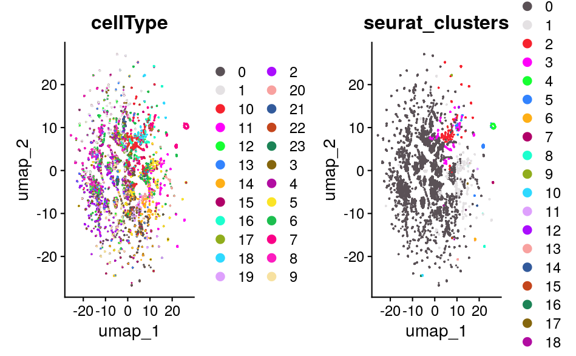

```r
DimPlot(neighbourhoodSeurat, group.by = c("cellType", "seurat_clusters"), cols = "polychrome", reduction = "umap")
```

Create seurat object for a cell type by neighbourhood matrix. Here we have a large feature space (numbers of cells) however low number of observations (number of cell types). Therefore we compute the UMAP using PCs however due to the low number of observations we need to set a lower value for n.neighbours.

[figure not shown]

We can also compute a graph embedding.

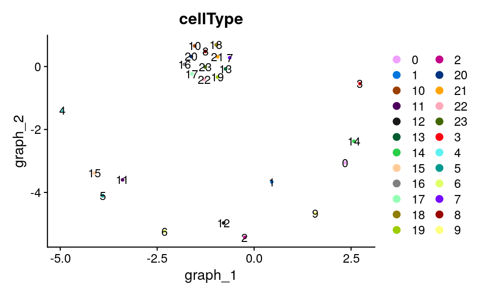

```r
neighbourhoodSeuratPrime = computeGraphEmbedding(neighbourhoodSeuratPrime)
DimPlot(neighbourhoodSeuratPrime,group.by = "cellType", cols = "alphabet", reduction = "graph", label = T)
```

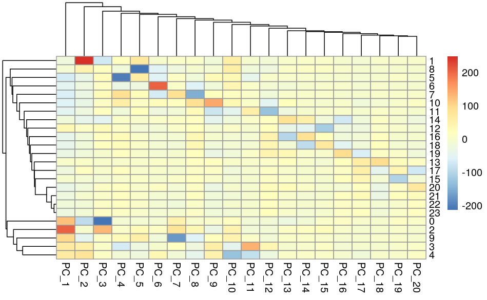

```r
library(pheatmap)

pca = Embeddings(neighbourhoodSeuratPrime, reduction = "pca")
res = pheatmap(pca)
```

Here we decide to cut the tree at the correct level to form 3 clusters.

```r
CTclust = cutree(res$tree_row, k = 3)
neighbourhoodSeuratPrime$seurat_clusters = factor(CTclust)
```

Lets investigate how neighbourhood clusters relate to cell type clusters.

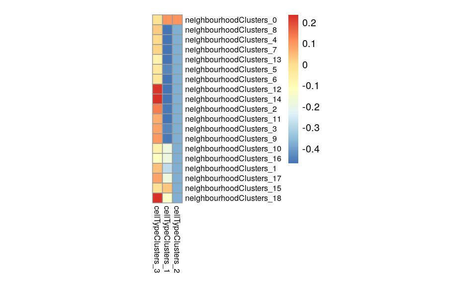

```r
averageExpMatrix = getAverageExpressionMatrix(neighbourhoodSeurat,neighbourhoodSeuratPrime)
averageExpMatrix = tagRowAndColNames(averageExpMatrix,
                                     ccTag='neighbourhoodClusters_',
                                     gcTag='cellTypeClusters_')
pheatmap(averageExpMatrix,
      treeheight_row=0,
      treeheight_col=0,
      fontsize_row=8,
      fontsize_col=8,
      cellheight=10,
      cellwidth=10)
```

```r
sankeyFromMatrix(averageExpMatrix)
```

[interactive chart not shown]

We can also investigate how cell clusters based on their neighbourhoods (here we call this domain) relate to cell clusters based on gene expression (here we call this CT - cell type).

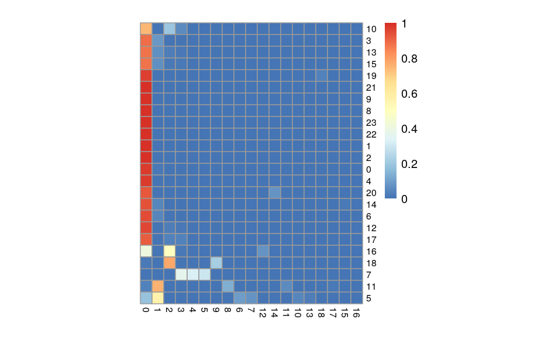

```r
CTDomain = table(neighbourhoodSeurat$cellType,neighbourhoodSeurat@active.ident)
CTDomain = CTDomain/rowSums(CTDomain)

pheatmap(CTDomain[,],
      treeheight_row=0,
      treeheight_col=0,
      fontsize_row=8,
      fontsize_col=8,
      cellheight=10,
      cellwidth=10)
```

```r
sankeyFromMatrix(CTDomain)
```

[interactive chart not shown]

If we have the xenium object loaded we can visualise cell types and neighbourhood clusters spatially.

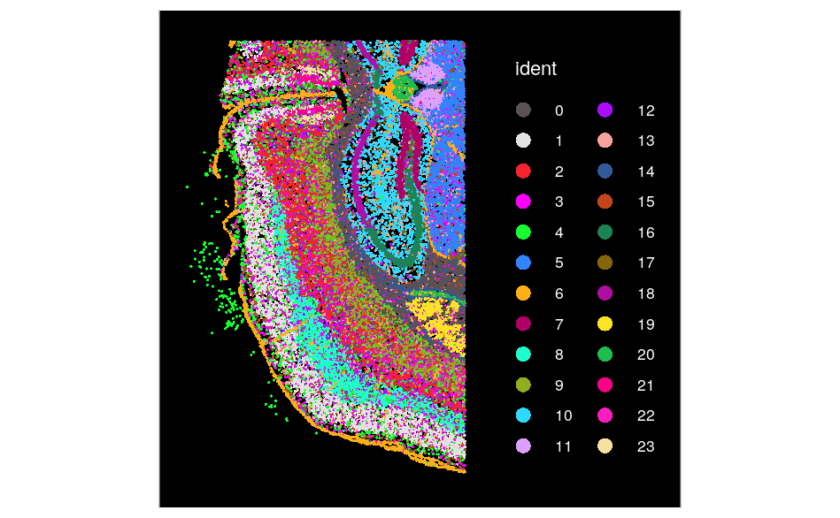

```r
ImageDimPlot(xenium.obj, cols = "polychrome", size = 0.75)
```

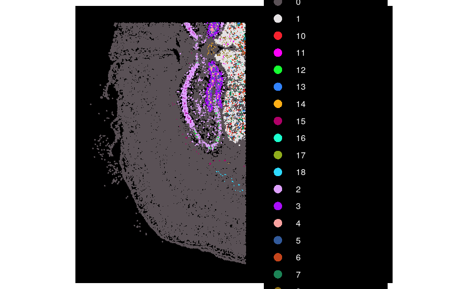

```r
xenium.obj$neighbourhoodCluster = factor(as.character(neighbourhoodSeurat$RNA_snn_res.0.01))
ImageDimPlot(xenium.obj, cols = "polychrome", size = 0.75,
             group.by = "neighbourhoodCluster")
```